# R data manipulation and joining

Height and Weight

In this exercise, we are going to explore a dataset of height and weight of teens

To load this data:

```r
tbl <- read.csv(file='heightweight.csv')
tbl
```

| sex | ageYear | ageMonth | heightIn | weightLb |
| --- | --- | --- | --- | --- |
| f | 11.91667 | 143 | 56.3 | 85.0 |
| f | 12.91667 | 155 | 62.3 | 105.0 |
| f | 12.75000 | 153 | 63.3 | 108.0 |
| f | 13.41667 | 161 | 59.0 | 92.0 |
| f | 15.91667 | 191 | 62.5 | 112.5 |
| f | 14.25000 | 171 | 62.5 | 112.0 |
| f | 15.41667 | 185 | 59.0 | 104.0 |
| f | 11.83333 | 142 | 56.5 | 69.0 |
| f | 13.33333 | 160 | 62.0 | 94.5 |
| f | 11.66667 | 140 | 53.8 | 68.5 |

[output cut: 227 more lines]

To explore this data, you can use the dplyr package (which has a variety of useful methods to filter, aggregate, and sort data frames), built-in R functions, or any other package you are familiar with.

Explore the data using the tools you have. You can use the summary function, plot some of the data or look at histograms, and so on. Try the following questions:

1. Calculate the weight in Kg

```r
tbl <- mutate(tbl,weightKg=weightLb/2.2)
tbl
```

| sex | ageYear | ageMonth | heightIn | weightLb | weightKg |
| --- | --- | --- | --- | --- | --- |
| f | 11.91667 | 143 | 56.3 | 85.0 | 38.63636 |
| f | 12.91667 | 155 | 62.3 | 105.0 | 47.72727 |
| f | 12.75000 | 153 | 63.3 | 108.0 | 49.09091 |
| f | 13.41667 | 161 | 59.0 | 92.0 | 41.81818 |
| f | 15.91667 | 191 | 62.5 | 112.5 | 51.13636 |
| f | 14.25000 | 171 | 62.5 | 112.0 | 50.90909 |
| f | 15.41667 | 185 | 59.0 | 104.0 | 47.27273 |
| f | 11.83333 | 142 | 56.5 | 69.0 | 31.36364 |
| f | 13.33333 | 160 | 62.0 | 94.5 | 42.95455 |
| f | 11.66667 | 140 | 53.8 | 68.5 | 31.13636 |

[output cut: 227 more lines]

2. Calculate the height in meters

```r
tbl <- mutate(tbl,heightm=heightIn*0.0254)
tbl
```

| sex | ageYear | ageMonth | heightIn | weightLb | weightKg | heightm |
| --- | --- | --- | --- | --- | --- | --- |
| f | 11.91667 | 143 | 56.3 | 85.0 | 38.63636 | 1.43002 |
| f | 12.91667 | 155 | 62.3 | 105.0 | 47.72727 | 1.58242 |
| f | 12.75000 | 153 | 63.3 | 108.0 | 49.09091 | 1.60782 |
| f | 13.41667 | 161 | 59.0 | 92.0 | 41.81818 | 1.49860 |
| f | 15.91667 | 191 | 62.5 | 112.5 | 51.13636 | 1.58750 |
| f | 14.25000 | 171 | 62.5 | 112.0 | 50.90909 | 1.58750 |
| f | 15.41667 | 185 | 59.0 | 104.0 | 47.27273 | 1.49860 |
| f | 11.83333 | 142 | 56.5 | 69.0 | 31.36364 | 1.43510 |
| f | 13.33333 | 160 | 62.0 | 94.5 | 42.95455 | 1.57480 |
| f | 11.66667 | 140 | 53.8 | 68.5 | 31.13636 | 1.36652 |

[output cut: 227 more lines]

3. Calculate BMI as kg/m2

```r
tbl <- mutate(tbl,bmi=weightKg/(heightm*heightm))
tbl
```

| sex | ageYear | ageMonth | heightIn | weightLb | weightKg | heightm | bmi |
| --- | --- | --- | --- | --- | --- | --- | --- |
| f | 11.91667 | 143 | 56.3 | 85.0 | 38.63636 | 1.43002 | 18.89348 |
| f | 12.91667 | 155 | 62.3 | 105.0 | 47.72727 | 1.58242 | 19.06001 |
| f | 12.75000 | 153 | 63.3 | 108.0 | 49.09091 | 1.60782 | 18.99005 |
| f | 13.41667 | 161 | 59.0 | 92.0 | 41.81818 | 1.49860 | 18.62060 |
| f | 15.91667 | 191 | 62.5 | 112.5 | 51.13636 | 1.58750 | 20.29095 |
| f | 14.25000 | 171 | 62.5 | 112.0 | 50.90909 | 1.58750 | 20.20077 |
| f | 15.41667 | 185 | 59.0 | 104.0 | 47.27273 | 1.49860 | 21.04937 |
| f | 11.83333 | 142 | 56.5 | 69.0 | 31.36364 | 1.43510 | 15.22867 |
| f | 13.33333 | 160 | 62.0 | 94.5 | 42.95455 | 1.57480 | 17.32042 |
| f | 11.66667 | 140 | 53.8 | 68.5 | 31.13636 | 1.36652 | 16.67385 |

[output cut: 227 more lines]

4. Plot the BMI by gender using a box plot

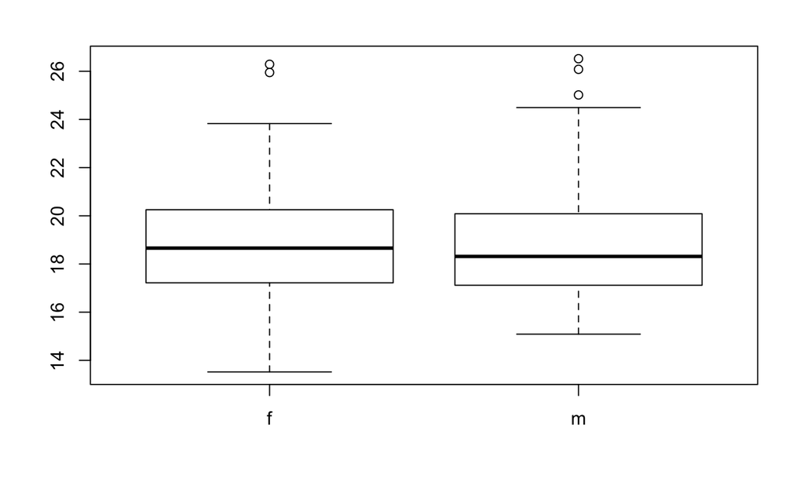

```r
boxplot(tbl$bmi ~ tbl$sex)
```

5. What is the min, max, mean and median height per gender?

```r
summarize(group_by(tbl,sex),mean.height=mean(heightIn),min.height=min(heightIn),max.height=max(heightIn),median.height=median(heightIn))
```

| sex | mean.height | min.height | max.height | median.height |
| --- | --- | --- | --- | --- |
| f | 60.52613 | 51.3 | 66.8 | 61.3 |
| m | 62.10317 | 50.5 | 72.0 | 61.9 |

Bacterial Community

In this exercise, we are going to explore the bacterial communities of 4 synthetic samples. This dataset contains the counts of reads that are classified into each taxa per sample. The first column is the taxonomic level where:

1. Kingdom
2. Phylum
3. Class
4. Order
5. Family
6. Genus
7. Species

To load the data use the command:

```r
mock <-read.table(file="mock_community.txt",sep='\t',header=TRUE)
```

To explore this data, you can use the dplyr package (which has a variety of useful methods to filter, aggregate, and sort data frames), built-in R functions, or any other package you are familiar with.

Explore the data using the tools you have. You can use the summary function, plot some of the data or look at histograms, and so on. Try the following questions:

1. What is the most abundant genus for each community?

```r
abun <- filter(mock, taxlevel == 6)
mock1 <- abun[order(abun$Mock1, decreasing = T),][1,]
mock2 <- abun[order(abun$Mock2, decreasing = T),][1,]
mock3 <- abun[order(abun$Mock3, decreasing = T),][1,]
mock4 <- abun[order(abun$Mock4, decreasing = T),][1,]
arrange(abun, desc(Mock1))
```

| taxlevel | taxon | Mock1 | Mock2 | Mock3 | Mock4 |
| --- | --- | --- | --- | --- | --- |
| 6 | Staphylococcus | 68 | 1327 | 256 | 295 |
| 6 | Listeria | 51 | 1196 | 186 | 310 |
| 6 | Bacillales_unclassified | 50 | 1472 | 380 | 446 |
| 6 | Salmonella | 49 | 965 | 216 | 251 |
| 6 | Enterobacteriaceae_unclassified | 37 | 888 | 195 | 207 |
| 6 | Enterococcus | 27 | 743 | 155 | 194 |
| 6 | Pseudomonas | 22 | 254 | 70 | 96 |
| 6 | Lactobacillus | 21 | 427 | 105 | 156 |
| 6 | Barnesiella | 3 | 0 | 0 | 0 |
| 6 | Bacillus | 2 | 0 | 0 | 0 |

[output cut: 55 more lines]

```r
arrange(abun, desc(Mock2))
```

| taxlevel | taxon | Mock1 | Mock2 | Mock3 | Mock4 |
| --- | --- | --- | --- | --- | --- |
| 6 | Bacillales_unclassified | 50 | 1472 | 380 | 446 |
| 6 | Staphylococcus | 68 | 1327 | 256 | 295 |
| 6 | Listeria | 51 | 1196 | 186 | 310 |
| 6 | Salmonella | 49 | 965 | 216 | 251 |
| 6 | Enterobacteriaceae_unclassified | 37 | 888 | 195 | 207 |
| 6 | Enterococcus | 27 | 743 | 155 | 194 |
| 6 | Lactobacillus | 21 | 427 | 105 | 156 |
| 6 | Pseudomonas | 22 | 254 | 70 | 96 |
| 6 | Streptococcus | 0 | 9 | 0 | 0 |
| 6 | Lachnospiraceae_unclassified | 1 | 9 | 5 | 0 |

[output cut: 55 more lines]

```r
arrange(abun, desc(Mock3))
```

| taxlevel | taxon | Mock1 | Mock2 | Mock3 | Mock4 |
| --- | --- | --- | --- | --- | --- |
| 6 | Bacillales_unclassified | 50 | 1472 | 380 | 446 |
| 6 | Staphylococcus | 68 | 1327 | 256 | 295 |
| 6 | Salmonella | 49 | 965 | 216 | 251 |
| 6 | Enterobacteriaceae_unclassified | 37 | 888 | 195 | 207 |
| 6 | Listeria | 51 | 1196 | 186 | 310 |
| 6 | Enterococcus | 27 | 743 | 155 | 194 |
| 6 | Lactobacillus | 21 | 427 | 105 | 156 |
| 6 | Pseudomonas | 22 | 254 | 70 | 96 |
| 6 | Lachnospiraceae_unclassified | 1 | 9 | 5 | 0 |
| 6 | Bacilli_unclassified | 0 | 0 | 2 | 0 |

[output cut: 55 more lines]

```r
arrange(abun, desc(Mock4))
```

| taxlevel | taxon | Mock1 | Mock2 | Mock3 | Mock4 |
| --- | --- | --- | --- | --- | --- |
| 6 | Bacillales_unclassified | 50 | 1472 | 380 | 446 |
| 6 | Listeria | 51 | 1196 | 186 | 310 |
| 6 | Staphylococcus | 68 | 1327 | 256 | 295 |
| 6 | Salmonella | 49 | 965 | 216 | 251 |
| 6 | Enterobacteriaceae_unclassified | 37 | 888 | 195 | 207 |
| 6 | Enterococcus | 27 | 743 | 155 | 194 |
| 6 | Lactobacillus | 21 | 427 | 105 | 156 |
| 6 | Pseudomonas | 22 | 254 | 70 | 96 |
| 6 | Actinomyces | 0 | 0 | 0 | 0 |
| 6 | Actinomycetaceae_unclassified | 0 | 0 | 0 | 0 |

[output cut: 55 more lines]

2. Which phylum has the highest read counts for all 4 samples?

```r
rcounts <- filter(mock, taxlevel == 2)
rcounts <- mutate(rcounts, TotalAbund = rowSums(rcounts[,3:6]))
#rcounts <- rcounts[order(rcounts$TotalAbund, decreasing = TRUE),][1,c(2,7)]
rcounts <- arrange(rcounts, desc(TotalAbund))[1,c(2,7)]
rcounts
```

|  | taxon | TotalAbund |
| --- | --- | --- |
| 1 | Firmicutes | 7897 |

3. Calculate the averge number of reads for each phyla

```r
mean.reads <- filter(mock, taxlevel ==2)
mean.reads <- mutate(mean.reads, phylaMeans = rowMeans(mean.reads[,3:6]))
mean.reads
```

| taxlevel | taxon | Mock1 | Mock2 | Mock3 | Mock4 | phylaMeans |
| --- | --- | --- | --- | --- | --- | --- |
| 2 | Actinobacteria | 0 | 0 | 0 | 0 | 0.00 |
| 2 | Bacteroidetes | 3 | 3 | 1 | 0 | 1.75 |
| 2 | Fusobacteria | 0 | 0 | 0 | 0 | 0.00 |
| 2 | Proteobacteria | 108 | 2111 | 482 | 554 | 813.75 |
| 2 | Verrucomicrobia | 0 | 1 | 0 | 0 | 0.25 |
| 2 | Firmicutes | 222 | 5185 | 1089 | 1401 | 1974.25 |

4.Create a new table with the sample name and the ratio of bacteroidetes/firmicutes.

```r
bactero <- t(filter(mock, taxon == 'Bacteroidetes'))[3:6,,drop=FALSE]
bactero
```

```
      [,1]
Mock1 "3"
Mock2 "3"
Mock3 "1"
Mock4 "0"
```

```r
firmicutes <- t(filter(mock, taxon == 'Firmicutes'))[3:6,,drop=FALSE]
firmicutes
```

```
      [,1]
Mock1 "222"
Mock2 "5185"
Mock3 "1089"
Mock4 "1401"
```

```r
ratios <- as.data.frame(cbind(as.numeric(bactero),as.numeric(firmicutes)))
ratios
```

| V1 | V2 |
| --- | --- |
| 3 | 222 |
| 3 | 5185 |
| 1 | 1089 |
| 0 | 1401 |

```r
colnames(ratios)<-c('Bacteroidetes','Firmicutes')
ratios <- mutate(ratios, ratio = Bacteroidetes/Firmicutes)
rownames(ratios) <- paste0("mock",seq(1,4,1))
ratios
```

|  | Bacteroidetes | Firmicutes | ratio |
| --- | --- | --- | --- |
| mock1 | 3 | 222 | 0.0135135135 |
| mock2 | 3 | 5185 | 0.0005785921 |
| mock3 | 1 | 1089 | 0.0009182736 |
| mock4 | 0 | 1401 | 0.0000000000 |

5. Which sample has the highest ratio?

```r
mock1
```

|  | taxlevel | taxon | Mock1 | Mock2 | Mock3 | Mock4 |
| --- | --- | --- | --- | --- | --- | --- |
| 37 | 6 | Staphylococcus | 68 | 1327 | 256 | 295 |

6. Create a table with just the genera (genus ie taxlevel=6). Add the total number of reads per genera and sort the table by the total.

```r
rcounts <- filter(mock, taxlevel == 6)
rcounts <- mutate(rcounts, TotalAbund = rowSums(rcounts[,3:6]))
#rcounts <- rcounts[order(rcounts$TotalAbund, decreasing = TRUE),]
rcounts <- arrange(rcounts, desc(TotalAbund))
rcounts
```

| taxlevel | taxon | Mock1 | Mock2 | Mock3 | Mock4 | TotalAbund |
| --- | --- | --- | --- | --- | --- | --- |
| 6 | Bacillales_unclassified | 50 | 1472 | 380 | 446 | 2348 |
| 6 | Staphylococcus | 68 | 1327 | 256 | 295 | 1946 |
| 6 | Listeria | 51 | 1196 | 186 | 310 | 1743 |
| 6 | Salmonella | 49 | 965 | 216 | 251 | 1481 |
| 6 | Enterobacteriaceae_unclassified | 37 | 888 | 195 | 207 | 1327 |
| 6 | Enterococcus | 27 | 743 | 155 | 194 | 1119 |
| 6 | Lactobacillus | 21 | 427 | 105 | 156 | 709 |
| 6 | Pseudomonas | 22 | 254 | 70 | 96 | 442 |
| 6 | Lachnospiraceae_unclassified | 1 | 9 | 5 | 0 | 15 |
| 6 | Streptococcus | 0 | 9 | 0 | 0 | 9 |

[output cut: 55 more lines]

7. Create a heatmap or stack bar plot of the genera by sample.

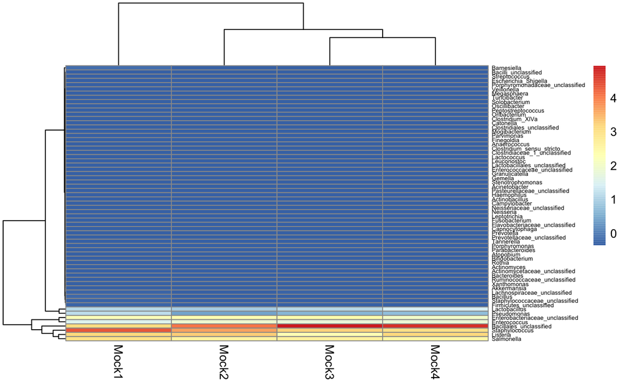

```r
library(pheatmap)
zscores <- scale(rcounts[,3:6])
rownames(zscores) <- rcounts$taxon
pheatmap(zscores, fontsize_row = 5)
```

8. Now load a second table of “real” samples:

```r
real <-read.table(file="real_community.txt",sep='\t',header=TRUE)
```

9. Join mock with real

```r
join.tbl <- inner_join(mock, real)
join.tbl
```

| taxlevel | taxon | Mock1 | Mock2 | Mock3 | Mock4 | Sample1 | Sample2 |
| --- | --- | --- | --- | --- | --- | --- | --- |
| 0 | Root | 333 | 7300 | 1572 | 1955 | 7211 | 18878 |
| 1 | Bacteria | 333 | 7300 | 1572 | 1955 | 7211 | 18878 |
| 2 | Actinobacteria | 0 | 0 | 0 | 0 | 28 | 306 |
| 3 | Actinobacteria | 0 | 0 | 0 | 0 | 28 | 306 |
| 4 | Actinomycetales | 0 | 0 | 0 | 0 | 15 | 226 |
| 5 | Actinomycetaceae | 0 | 0 | 0 | 0 | 15 | 226 |
| 6 | Actinomyces | 0 | 0 | 0 | 0 | 15 | 225 |
| 6 | Actinomycetaceae_unclassified | 0 | 0 | 0 | 0 | 0 | 1 |
| 5 | Micrococcaceae | 0 | 0 | 0 | 0 | 0 | 0 |
| 6 | Rothia | 0 | 0 | 0 | 0 | 0 | 0 |

[output cut: 136 more lines]

10. Create a table at any taxa level (ie phylum, order, etc) and plot taxonomic abundance at of samples with stack barplots

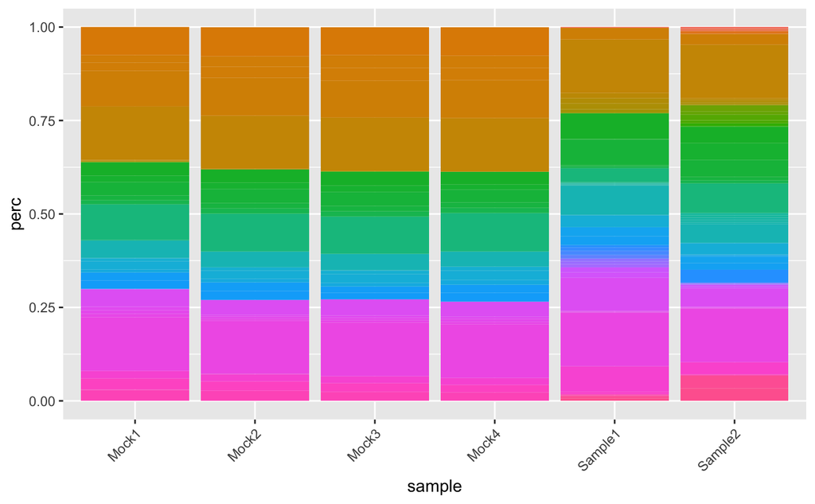

```r
library(reshape)
library(ggplot2)
total <- as.data.frame(colSums(join.tbl[,3:8]))
colnames(total)<-"nseqs"
total$sample <- rownames(total)
taxct <- melt(join.tbl,id.vars=c('taxon','taxlevel'))
names(taxct) <- c('taxname','level','sample','taxct')
taxct <- merge(taxct,total,by='sample')
taxct <- mutate(taxct,perc=round(taxct/nseqs, digits = 7))
min.seq<- min(total$nseqs)
taxct <- mutate(taxct,norm=min.seq*perc)
ggplot(taxct, aes(x = sample, y = perc,fill=taxname)) + geom_bar(stat='identity') + theme(axis.text.x = element_text(angle = 45, hjust = 1), legend.position = 'none')
```